# Exploratory_Data_Analysis

## Exploratory Data Analysis

Exploratory Data Analysis is an important step before applying the actual machine learning algorithms on the data. It gives a quick insight into the data, and helps us understand the data better. We shall look at 3 different ways to explore data today:

1. Visual Exploratory Analysis
2. Statistical Analysis
3. Descriptive Explorations

```python
import pandas as pd
import numpy as np
import matplotlib.pyplot as plt
import seaborn as sns
from scipy.stats import chi2_contingency
```

### Reading in the Data

```python
#Reading the input files
data=pd.read_csv('data/diabetic_data.csv')
features=pd.read_csv('data/feature_descriptions.csv')
mapping=pd.read_csv('data/IDs_mapping.csv')
```

```python
print data.describe
print data.info(verbose=True)
print features.describe()
print mapping.describe()
```

```
<bound method DataFrame.describe of         encounter_id  patient_nbr             race  gender       age weight  \
0            2278392      8222157        Caucasian  Female    [0-10)      ?
1             149190     55629189        Caucasian  Female   [10-20)      ?
2              64410     86047875  AfricanAmerican  Female   [20-30)      ?
3             500364     82442376        Caucasian    Male   [30-40)      ?
4              16680     42519267        Caucasian    Male   [40-50)      ?
5              35754     82637451        Caucasian    Male   [50-60)      ?
6              55842     84259809        Caucasian    Male   [60-70)      ?
7              63768    114882984        Caucasian    Male   [70-80)      ?
8              12522     48330783        Caucasian  Female   [80-90)      ?
9              15738     63555939        Caucasian  Female  [90-100)      ?
10             28236     89869032  AfricanAmerican  Female   [40-50)      ?
11             36900     77391171  AfricanAmerican    Male   [60-70)      ?
12             40926     85504905        Caucasian  Female   [40-50)      ?
13             42570     77586282        Caucasian    Male   [80-90)      ?
```

[output cut: 436 more lines]

### Visualizations

Visualizations are an important way of getting to know your data and building hypotheses. Following is an exploration of different fields in our data, to get a better understanding.

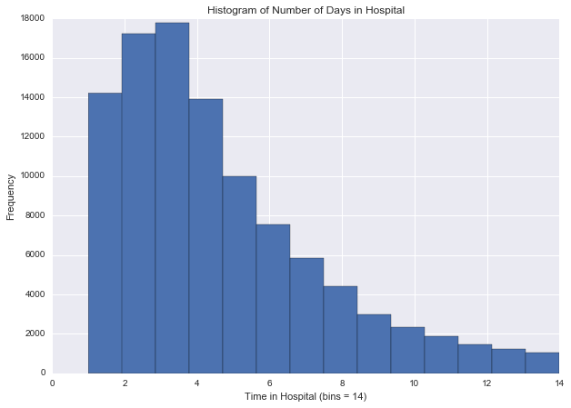

```python
%matplotlib inline
bins = 14
h = data['time_in_hospital'].plot.hist(bins=bins, figsize=(10, 7),
                                             title='Histogram of Number of Days in Hospital')
h.set_xlabel('Time in Hospital (bins = {})'.format(bins))
```

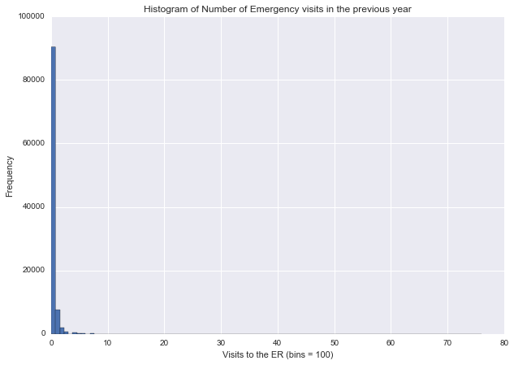

```python
bins = 100
h = data['number_emergency'].plot.hist(bins=bins,figsize=(10, 7),
                      title='Histogram of Number of Emergency visits in the previous year')
h.set_xlabel('Visits to the ER (bins = {})'.format(bins))
```

```python
df2=data[['admission_type_id','num_lab_procedures','num_procedures','num_medications']]
print df2.head()
```

```
   admission_type_id  num_lab_procedures  num_procedures  num_medications
0                  6                  41               0                1
1                  1                  59               0               18
2                  1                  11               5               13
3                  1                  44               1               16
4                  1                  51               0                8
```

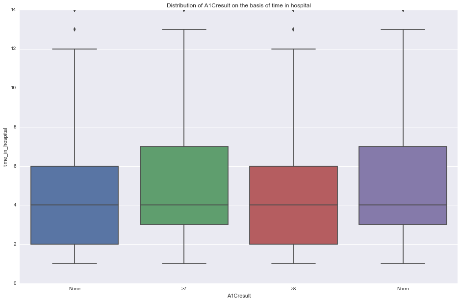

```python
plt.figure(figsize=(16, 10))
ax = sns.boxplot(x = "A1Cresult", y = "time_in_hospital", data=data)
ax.set(title='Distribution of A1Cresult on the basis of time in hospital')
```

[output not shown]

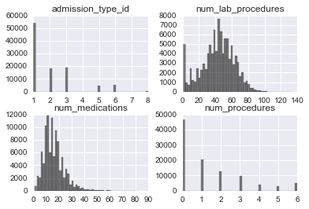

```python
df2.hist(color='k', alpha=0.5, bins=50)
```

The above visualisation Gives a quick glance into the frequency of the various numeric variables. The most common type of admission type seems to be 1, and the least 8 with barely any occurences of 4 and 7.

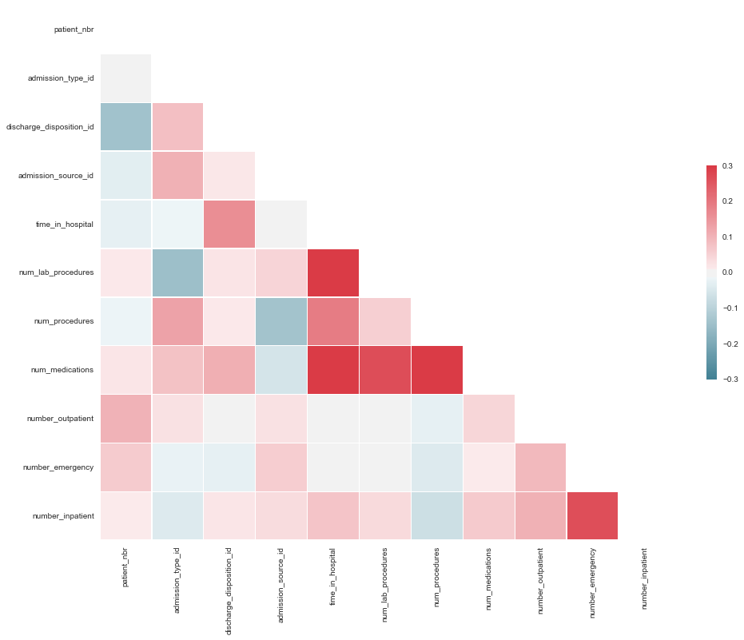

```python
numerics = ['int16', 'int32', 'int64', 'float16', 'float32', 'float64']
diabetic_nums = data.select_dtypes(include=numerics).iloc[:, 1:-1]
corr = diabetic_nums.corr()
corr
sns.set(style='white')
mask = np.zeros_like(corr, dtype=bool)
mask[np.triu_indices_from(mask)] = True
f, ax = plt.subplots(figsize=(16, 12))
cmap = sns.diverging_palette(220, 10, as_cmap=True)
sns.heatmap(corr, mask=mask, cmap=cmap, vmax=.3, linewidths=0.5, cbar_kws={"shrink": 0.4}, ax=ax)
```

The Heatmap gives interesting insights into the data and is also a good way to formulate various hypotheses to test. For example, there seems to be a very high correlation between the number of days a patient is admitted in hospital and the amount of medications he is given. However, the number of procedures performed on a patient seems negatively correlated with the number of visits to inpatient the previous year.

The plot below shows a snapshot of all the numeric fields in our data.

[output not shown]

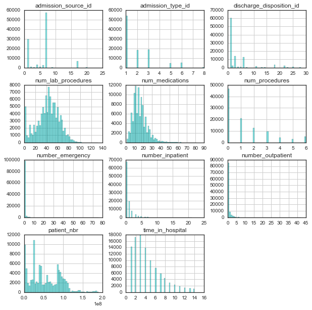

```python
diabetic_nums.hist(color='c', alpha=0.5, bins=50,figsize=(10,10))
```